# uabRelatorioFinalLimpo

Análise das tabelas do TCU

Frederico Firmo de Souza Cruz

## Leitura dos dados do arquivo "pagamentos_irregulares.csv do TCU

## Tabela com todos os dados

Os dados da tabela feita por auditores do TCU na qual constavam 1729 linhas com o nome de bolsistas e valores de bolsa recebidos. Isto é a tabela tem a data de pagamento, valor da bolsa ano e mes de referência além do curso. Todas as bolsas desta tabela foram consideradas irregulares utilizando como critério a ausência do nome dos bolsistas na plataforma Educacional Moodle e num cadastros da Universidade. A alegação é que teriam recebido sem realizar atividades. Nenhum bolsista ou conjunto de bolsistas foi investigado e ou chamado a depor. Posteriormente os auditores de aceitaram informalmente que os critérios utilizados não eram adequados e ou suficientes para abalizar as suposições de irregularidade.

|  | Nome Bolsista | Curso | Mes | Ano | Valor | Data Pagamento Bolsa |
| --- | --- | --- | --- | --- | --- | --- |
| 0 | ALACOQUE LORENZINI ERDMANN | GESTAO EM SAUDE | 4 | 2014 | 1300.0 | 2014-05-05 |
| 1 | ALACOQUE LORENZINI ERDMANN | GESTAO EM SAUDE | 5 | 2014 | 1300.0 | 2014-06-02 |
| 2 | ALACOQUE LORENZINI ERDMANN | GESTAO EM SAUDE | 6 | 2014 | 1300.0 | 2014-07-03 |
| 3 | ALACOQUE LORENZINI ERDMANN | GESTAO EM SAUDE | 7 | 2014 | 1300.0 | 2014-07-04 |
| 4 | ALESSANDRO VICENTE CUSTODIO | GESTAO PUBLICA MUNICIPAL | 6 | 2012 | 1300.0 | 2012-07-24 |

## Lista ordenada de cursos

Os bolsistas atuavam em 20 cursos de EAD como listado abaixo. Cada um dos cursos tem um Coordenador, responsável pela seleção e escolha de bolsistas e pelo acompanhamento das atividades do curso. Cada bolsista assina termo de responsabilidade e e assina o contrato de bolsa. Sendo que este último é encaminhado a CAPES que é orgão pagador. Os pagamentos de bolsista é feito diretamente ao bolsista, pela CAPES sem intermediação de coordenadores. O programa da CAPES deteta pagamentos duplos e nenhum bolsista pode receber mais do que uma bolsa. A ausência de registros segundo os critérios apresentados pelo TCU, foram contestados, visto que existem outras registros oficiais de posse da universidade de capes. Apesar de aceitarem a insuficiência dos critérios, o relatório do TCU continuou a ser usado nas acusações penais e administrativas. Nenhum bolsista e ou coordenador de curso foi chamado a depor. Endereçaram os questionamentos apenas à Coordenação Geral da UAB, sendo que esta não tem prerrogativa de interferir nos cursos específicos. A coordenadoria UAB, analisa apenas a realização do curso.

## Lista de cursos

```
0                                       GESTAO EM SAUDE
1                              GESTAO PUBLICA MUNICIPAL
2                                        GESTAO PUBLICA
3                                         ADMINISTRACAO
4                                   CIENCIAS ECONOMICAS
5                                    CIENCIAS CONTABEIS
6        PACC PROG ANUAL DE CAPACITAÇÃO CONTINUADA 2012
7                                       LETRAS ESPANHOL
8                                 ADMINISTRACAO PUBLICA
9               SECADI - GENERO E DIVERSIDADE NA ESCOLA
10                                               FISICA
11                                     LETRAS PORTUGUES
12    PACC - PROG. ANUAL DE CAPACITAÇÃO CONTINUADA 2013
13                  FORMAÇÃO DA EQUIPE MULTIDISCIPLINAR
14                                        LETRAS INGLES
15                                            FILOSOFIA
16                                           MATEMATICA
17                              FOMENTO AO USO DAS TICS
18                                  CIENCIAS BIOLOGICAS
19         SECADI - FORMAÇÃO DA EQUIPE MULTIDISCIPLINAR
Name: Curso, dtype: object
```

## Lista de bolsistas

A lista total de pagamentos mensais de bolsas, indicando 1728 supostas irregularidades, correspondem de fato a 179 bolsas concedidas a partir de critérios de seleção sob responsabilidade de cada coordenador de curso e com o objetivo de realização do curso. Embora possa haver variações de curso para curso as seleções de tutores, monitores, webdesign, especialistas em tecnologia da informação etc... eram feitas a partir de editais abertos para alunos, funcionários da universidade, visto que bolsistas CAPES tinham que ter vinculo com a universidade. Os professores eram escolhidos e indicados pelos Colegiados de Departamentos. O periodo a que se refere a denuncia corresponde ao intervalo de 4 anos e 179 bolsistas. A explicitação do número de anos e de 179 supostas irregularidades, diminuiria sem dúvida o impacto midiático da denúncia. Para a imprensa foi anunciado o montante total de R$ 1839220,00 em desvios. Não foi mencionado que correspondiam ao gasto em quatro anos, isto é 48 meses com 179 bolsistas atuando em 20 cursos diferentes de EAD, com polos em várias cidades de Santa Catarina e alguns polos em outros estados brasileiros. Uma conta simples montante total =18329220 dividido por 179 bolsistas e dividido por 48 meses nos dá um "suposto rombo nos cofres públicos " de 215 reais por mes para cada um dos bolsistas. Obviamente este deve estar muito abaixo do que foi pago mensalmente para os auditores do TCU construirem este relatório e esta tabela e criarem todo um quadro acusatório. Mas vamos analisar abaixo os dados das tabelas . Apenas algumas linhas da tabela com a lista dos bolsistas é mostrado abaixo por falta de espaço .

```
Numero de bolsistas=  179
```

```
0        ALACOQUE LORENZINI ERDMANN
1       ALESSANDRO VICENTE CUSTODIO
2         ALEXANDRE AMORIM DE SOUZA
3        ALEXANDRE SANTOS VEDOVELLI
4          ALISON ROBERTO GONCALVES
                   ...
174            VANDERLEI DOS SANTOS
175          VANESSA FERREIRA BENTO
176             VICTOR BURIGO SOUZA
177            VIVIANE MARIA BEUTER
178    WERNER ARTUR JORGE WEINZIERL
Name: Nome Bolsista, Length: 179, dtype: object
```

## Dados por curso

Para efetuar uma análise que deveria ter sido feita pelos auditores vamos, começar separando os montantes totais de pagamentos por curso

## Montante total de supostos pagamentos irregulares por curso

```
Curso
ADMINISTRACAO                                        728120.0
ADMINISTRACAO PUBLICA                                276835.0
CIENCIAS BIOLOGICAS                                    9330.0
CIENCIAS CONTABEIS                                   139360.0
CIENCIAS ECONOMICAS                                    9100.0
FILOSOFIA                                             47520.0
FISICA                                                34725.0
FOMENTO AO USO DAS TICS                                9945.0
FORMAÇÃO DA EQUIPE MULTIDISCIPLINAR                    9000.0
GESTAO EM SAUDE                                      134125.0
GESTAO PUBLICA                                        50600.0
GESTAO PUBLICA MUNICIPAL                              42400.0
LETRAS ESPANHOL                                      139370.0
LETRAS INGLES                                         13920.0
LETRAS PORTUGUES                                      72695.0
MATEMATICA                                            16675.0
PACC - PROG. ANUAL DE CAPACITAÇÃO CONTINUADA 2013     40500.0
PACC PROG ANUAL DE CAPACITAÇÃO CONTINUADA 2012         6025.0
SECADI - FORMAÇÃO DA EQUIPE MULTIDISCIPLINAR           7800.0
SECADI - GENERO E DIVERSIDADE NA ESCOLA               51175.0
Name: Valor, dtype: float64
```

## Gráfico com os gastos totais por curso

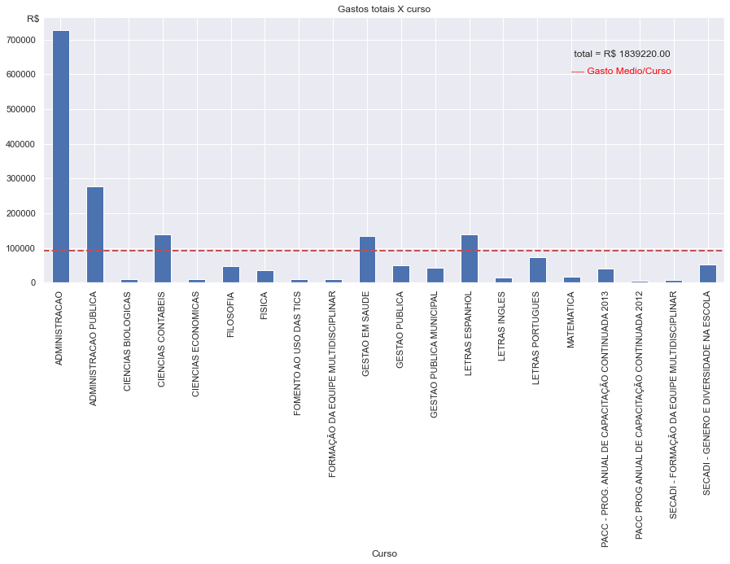

## Cursos com gastos acima da média.

Na tabela abaixo o montante gasto pelos 5 cursos com gastos acima da média.

```
Curso
ADMINISTRACAO            728120.0
ADMINISTRACAO PUBLICA    276835.0
CIENCIAS CONTABEIS       139360.0
GESTAO EM SAUDE          134125.0
LETRAS ESPANHOL          139370.0
Name: Valor, dtype: float64
```

## Total bolsas por bolsistas por curso

Na analise que apresento aqui vou analisar os ganhos por bolsista do curso com maior gasto, Curso de Administração. Esta análise foi feita para todos os cursos.

```
Administração
numero total de bolsistas = 55
```

```
Nome Bolsista
ALESSANDRO VICENTE CUSTODIO                 5200.0
ALEXANDRE AMORIM DE SOUZA                   2600.0
ANGELICA DA SILVA E SILVA                   7700.0
ANNYE CRISTINY TESSARO                     10400.0
AUREO MAFRA DE MORAES                      14300.0
CARLA MARGARETE BUCHELE                    24200.0
CECILIA ESTELA GIUFFRA PALOMINO             6600.0
CESAR DUARTE SOUTO MAIOR                   11000.0
CLEDISON AMBROZIO MARQUES                  19125.0
CRISTIANE MORAES DA SILVA                   8800.0
DANILO JOSE ALANO MELO                      1100.0
DEISIRE AGLAE AMARAL                        8800.0
ELDER SEMPREBOM                             1300.0
ERIC DUARTE FERREIRA                        2600.0
ERIK PERSSON SOUZA                          8800.0
FELLIPE NETTO CANCELLIER                   22100.0
FERNANDA MATTE CAVALCANTE                   3300.0
FERNANDA SALVADOR ALVES                    24700.0
FRANCISCO EDUARDO GONCALVES SILVEIRA       23400.0
GABRIEL MORAES HERLING                     13200.0
JADIR ADEMAR DAS CHAGAS                    17600.0
JORDANA MARIA RAMOS CARDOSO                18700.0
JOSE CARLOS VIEIRA                         27300.0
JOSE FRANCISCO BERNARDES                   19500.0
JOSE ROBERTO CASTELLO BRANCO DE FREITAS    18700.0
JULIANA TATIANE VITAL                      23400.0
JULIANA VACCARI DE ABREU DA ROSA           19800.0
KARIN VIEIRA DA SILVA                       4400.0
LEANDRO SCHMITZ                             4400.0
LUCIANE PAULA VITAL                        40300.0
LUIZ SALGADO KLAES                         27300.0
MARCELO AUGUSTO MENEZES DELUCA              7800.0
MARCIA BARROS DE SALES                      3900.0
MARCIA REGINA PEREIRA SAGAZ                24200.0
MARCIO CECHETTO                             2295.0
MARCIO ROSA BARBOSA                         9945.0
MARCUS VENICIUS ANDRADE DE LIMA             5200.0
MARIA APARECIDA SILVA ALVES                11000.0
MARIANA OLIVEIRA MORITZ                    14105.0
MAURICIO RISSI                              7700.0
MAURICIO ROQUE SERVA DE OLIVEIRA            6500.0
MILEIDE MARLETE FERREIRA LEAL SABINO       18700.0
MONICA RAMOS CARNEIRO                       2200.0
ODIMAR LORENSET                             7800.0
PATRICIA REGINA DA COSTA                   16065.0
PAULO OTOLINI GARRIDO                       6500.0
RENATA DE MARTINS FARIA VIEIRA HEIS         2200.0
ROBERTO CARLOS ALVES                       28600.0
ROSANGELA TEREZINHA EMERIM MOREIRA         26400.0
STEPHANIE BUENO ZANINCHELLI                18700.0
TAIS GOMES PRATES                          17600.0
THIAGO COELHO SOARES                       10400.0
VALTER SAURIN                              26000.0
VANDERLEI DOS SANTOS                        1300.0
VICTOR BURIGO SOUZA                        12385.0
Name: Valor, dtype: float64
```

```
Valor mínimo recebido por bolsista =R$ 765.00
Valor máximo recebido por bolsista =R$ 40300.00
Valor medio recebido por bolsista =R$ 8247.62
```

## Analise do total máximo recebido e do bolsista com maior número de bolsas.

```
Numero minimo de bolsas por bolsista=  1
Numero maximo de bolsas por bolsista= 48
Numero medio de bolsas por bolsista=  7
```

### O numero de bolsas media por bolsista é 7,e os dados indicam que 75% recebeu até 9 bolsas. Estes dados são compatíveis com um docente em atividade em aproximadamente 2 semestres num ano. Onde cada semestre corresponde a quatro a cinco meses de período letivo.

### Vamos agora extrair os Bolsistas com ganhos superiores a $ R\$15600,00 $.

### Este limite corresponde a uma bolsa de $R\$ 1300,00 $ por mes durante um ano. Mas observar que os resultados só se tornam significativos se analisarmos os períodos de bolsa de cada um dos bolsistas e o numero de cursos e polos que serviram.

## Lista de bolsistas e cursos que receberam acima de $ R\$15600,00 $.

```
Curso                                              Nome Bolsista
ADMINISTRACAO                                      CARLA MARGARETE BUCHELE                    24200.0
                                                   CLEDISON AMBROZIO MARQUES                  19125.0
                                                   FELLIPE NETTO CANCELLIER                   22100.0
                                                   FERNANDA SALVADOR ALVES                    24700.0
                                                   FRANCISCO EDUARDO GONCALVES SILVEIRA       23400.0
                                                   JADIR ADEMAR DAS CHAGAS                    17600.0
                                                   JORDANA MARIA RAMOS CARDOSO                18700.0
                                                   JOSE CARLOS VIEIRA                         27300.0
                                                   JOSE FRANCISCO BERNARDES                   19500.0
                                                   JOSE ROBERTO CASTELLO BRANCO DE FREITAS    18700.0
                                                   JULIANA TATIANE VITAL                      23400.0
                                                   JULIANA VACCARI DE ABREU DA ROSA           19800.0
                                                   LUCIANE PAULA VITAL                        40300.0
                                                   LUIZ SALGADO KLAES                         27300.0
                                                   MARCIA REGINA PEREIRA SAGAZ                24200.0
                                                   MILEIDE MARLETE FERREIRA LEAL SABINO       18700.0
                                                   PATRICIA REGINA DA COSTA                   16065.0
                                                   ROBERTO CARLOS ALVES                       28600.0
                                                   ROSANGELA TEREZINHA EMERIM MOREIRA         26400.0
                                                   STEPHANIE BUENO ZANINCHELLI                18700.0
                                                   TAIS GOMES PRATES                          17600.0
                                                   VALTER SAURIN                              26000.0
ADMINISTRACAO PUBLICA                              JORDANA MARIA RAMOS CARDOSO                19800.0
                                                   JOSE ROBERTO CASTELLO BRANCO DE FREITAS    37700.0
                                                   JUAN CARLOS COTO FLORES                    26400.0
                                                   MARIA APARECIDA SILVA ALVES                37700.0
                                                   MILEIDE MARLETE FERREIRA LEAL SABINO       37700.0
                                                   STEPHANIE BUENO ZANINCHELLI                36100.0
CIENCIAS CONTABEIS                                 ANTONIO LIDIO NILES FILHO                  23715.0
                                                   GIOVANA SCHUELTER                          22100.0
                                                   JAQUELINE ROSSATO                          36720.0
GESTAO EM SAUDE                                    GIOVANA DORNELES CALLEGARO                 19890.0
LETRAS ESPANHOL                                    ARIANE GIRONDI                             17600.0
                                                   MYRIAN VASQUES OYARZABAL                   35910.0
PACC - PROG. ANUAL DE CAPACITAÇÃO CONTINUADA 2013  CARLA VIEIRA LOPES                         19500.0
Name: Valor, dtype: float64
```

```
Curso                                              Nome Bolsista
ADMINISTRACAO                                      CARLA MARGARETE BUCHELE                    22
                                                   CLEDISON AMBROZIO MARQUES                  25
                                                   FELLIPE NETTO CANCELLIER                   17
                                                   FERNANDA SALVADOR ALVES                    19
                                                   FRANCISCO EDUARDO GONCALVES SILVEIRA       18
                                                   JADIR ADEMAR DAS CHAGAS                    16
                                                   JORDANA MARIA RAMOS CARDOSO                17
                                                   JOSE CARLOS VIEIRA                         21
                                                   JOSE FRANCISCO BERNARDES                   15
                                                   JOSE ROBERTO CASTELLO BRANCO DE FREITAS    17
                                                   JULIANA TATIANE VITAL                      18
                                                   JULIANA VACCARI DE ABREU DA ROSA           18
                                                   LUCIANE PAULA VITAL                        31
                                                   LUIZ SALGADO KLAES                         21
                                                   MARCIA REGINA PEREIRA SAGAZ                22
                                                   MARCIO ROSA BARBOSA                        13
                                                   MARIANA OLIVEIRA MORITZ                    18
                                                   MILEIDE MARLETE FERREIRA LEAL SABINO       17
                                                   PATRICIA REGINA DA COSTA                   21
                                                   ROBERTO CARLOS ALVES                       26
                                                   ROSANGELA TEREZINHA EMERIM MOREIRA         24
                                                   STEPHANIE BUENO ZANINCHELLI                17
                                                   TAIS GOMES PRATES                          16
                                                   VALTER SAURIN                              20
                                                   VICTOR BURIGO SOUZA                        14
ADMINISTRACAO PUBLICA                              JORDANA MARIA RAMOS CARDOSO                18
                                                   JOSE ROBERTO CASTELLO BRANCO DE FREITAS    29
                                                   JUAN CARLOS COTO FLORES                    24
                                                   MARIA APARECIDA SILVA ALVES                29
                                                   MILEIDE MARLETE FERREIRA LEAL SABINO       29
                                                   STEPHANIE BUENO ZANINCHELLI                29
CIENCIAS CONTABEIS                                 ANTONIO LIDIO NILES FILHO                  31
                                                   GIOVANA SCHUELTER                          17
                                                   JAQUELINE ROSSATO                          48
FISICA                                             ANTONIO LIDIO NILES FILHO                  17
GESTAO EM SAUDE                                    BRUNA PEDROSO CANEVER                      17
                                                   GIOVANA DORNELES CALLEGARO                 26
LETRAS ESPANHOL                                    ARIANE GIRONDI                             16
                                                   CHRISTIAN JEAN ABES                        13
                                                   MYRIAN VASQUES OYARZABAL                   43
LETRAS PORTUGUES                                   VALDETE DA CUNHA                           13
PACC - PROG. ANUAL DE CAPACITAÇÃO CONTINUADA 2013  CARLA VIEIRA LOPES                         15
Name: Mes, dtype: int64
```

```
bolsistas com ganho superior a R$15600=  35
```

```
 numero de bolsistas com mais do que 12 bolsas=  42
```